# UMCH

Cora Boyoung Jung, Enoch Mwesigwa, Jordan Severn

## Import csv

```r
UMCHdata <- read_csv("https://raw.githubusercontent.com/Cora-Boyoung-Jung/UMCH/main/data/UMCH_p.csv",
                     col_types = cols(Birthdate = col_date(format = "%m/%d/%Y"),
                                      Age = col_integer()))
glimpse(UMCHdata)
```

```
## Rows: 36
## Columns: 22
## $ Filename                        <chr> "failed_infant_1", "failed_infant_2",…
## $ Birthdate                       <date> 2020-05-26, 2020-06-03, 2020-03-05, …
## $ AgeGroup                        <chr> "infant", "infant", "infant", "infant…
## $ Age                             <int> 0, 0, 0, 0, 0, 0, 1, 1, 1, 1, 1, 1, 1…
## $ Gender                          <chr> "Male", "Female", "Female", "Female",…
## $ PhysicalDevelopment             <dbl> 4.0, 4.0, 13.0, 23.0, 6.0, 24.0, 19.0…
## $ LanguageDevelopment             <dbl> 7.0, 5.0, 11.0, 32.0, 11.0, 36.0, 21.…
## $ Adaptive_SelfHelp               <dbl> 3, 3, 4, 6, 3, 11, 8, 8, 8, 6, 7, 8, …
## $ Adaptive_SocialEmotional        <dbl> 3, 0, 5, 14, 5, 16, 12, 12, 12, 12, 1…
## $ AcademicAndCognitive            <dbl> NA, NA, NA, NA, NA, NA, NA, NA, NA, N…
## $ AcademicAndCognitive_Maths      <dbl> NA, NA, NA, NA, NA, NA, NA, NA, NA, N…
## $ AcademicAndCognitive_Literacy   <dbl> NA, NA, NA, NA, NA, NA, NA, NA, NA, N…
## $ PhysicalDevelopment_P           <dbl> 14.29, 14.29, 46.43, 82.14, 21.43, 85…
## $ LanguageDevelopment_P           <dbl> 15.91, 11.36, 25.00, 72.73, 25.00, 81…
## $ Adaptive_SelfHelp_P             <dbl> 25.00, 25.00, 33.33, 50.00, 25.00, 91…
## $ Adaptive_SocialEmotional_P      <dbl> 18.75, 0.00, 31.25, 87.50, 31.25, 100…
## $ AcademicAndCognitive_P          <dbl> NA, NA, NA, NA, NA, NA, NA, NA, NA, N…
## $ AcademicAndCognitive_Maths_P    <dbl> NA, NA, NA, NA, NA, NA, NA, NA, NA, N…
## $ AcademicAndCognitive_Literacy_P <dbl> NA, NA, NA, NA, NA, NA, NA, NA, NA, N…
## $ TotalScore                      <dbl> 17.0, 12.0, 33.0, 75.0, 25.0, 87.0, 6…
## $ Status                          <chr> "failed", "failed", "failed", "passed…
## $ Examiner                        <chr> "Sam McGowen", "Sam McGowen", "Sam Mc…
```

## Tidying data

```r
UMCH <- UMCHdata %>% mutate(Status = tolower(Status))
neworder <- c("infant","toddler","two_year", "three_year", "four_year")

UMCH <- arrange(transform(UMCH,
             AgeGroup=factor(AgeGroup,levels=neworder)),AgeGroup)
```

## Exploring data set

```r
head(UMCH)
```

|  | Filename | Birthdate | AgeGroup | Age | Gender | PhysicalDevelopment | LanguageDevelopment | Adaptive_SelfHelp | Adaptive_SocialEmotional | AcademicAndCognitive | AcademicAndCognitive_Maths | AcademicAndCognitive_Literacy | PhysicalDevelopment_P | LanguageDevelopment_P | Adaptive_SelfHelp_P | Adaptive_SocialEmotional_P | AcademicAndCognitive_P | AcademicAndCognitive_Maths_P | AcademicAndCognitive_Literacy_P | TotalScore | Status | Examiner |
| --- | --- | --- | --- | --- | --- | --- | --- | --- | --- | --- | --- | --- | --- | --- | --- | --- | --- | --- | --- | --- | --- | --- |
| 1 | failed_infant_1 | 2020-05-26 | infant | 0 | Male | 4 | 7 | 3 | 3 | NA | NA | NA | 14.29 | 15.91 | 25.00 | 18.75 | NA | NA | NA | 17 | failed | Sam McGowen |
| 2 | failed_infant_2 | 2020-06-03 | infant | 0 | Female | 4 | 5 | 3 | 0 | NA | NA | NA | 14.29 | 11.36 | 25.00 | 0.00 | NA | NA | NA | 12 | failed | Sam McGowen |
| 3 | failed_infant_3* | 2020-03-05 | infant | 0 | Female | 13 | 11 | 4 | 5 | NA | NA | NA | 46.43 | 25.00 | 33.33 | 31.25 | NA | NA | NA | 33 | failed | Sam McGowen |
| 4 | passed_infant_1 | 2019-11-13 | infant | 0 | Female | 23 | 32 | 6 | 14 | NA | NA | NA | 82.14 | 72.73 | 50.00 | 87.50 | NA | NA | NA | 75 | passed | Melissa Swanson |
| 5 | passed_infant_2 | 2020-07-01 | infant | 0 | Male | 6 | 11 | 3 | 5 | NA | NA | NA | 21.43 | 25.00 | 25.00 | 31.25 | NA | NA | NA | 25 | passed | Sam McGowen |
| 6 | passed_infant_3 | 2019-11-30 | infant | 0 | Male | 24 | 36 | 11 | 16 | NA | NA | NA | 85.71 | 81.82 | 91.67 | 100.00 | NA | NA | NA | 87 | passed | Melissa Swanson |

```r
summary(UMCH)
```

```
##    Filename           Birthdate                AgeGroup       Age
##  Length:36          Min.   :2016-01-21   infant    : 6   Min.   :0.000
##  Class :character   1st Qu.:2017-06-26   toddler   : 9   1st Qu.:1.000
##  Mode  :character   Median :2018-04-10   two_year  :11   Median :2.000
##                     Mean   :2018-04-29   three_year: 4   Mean   :1.861
##                     3rd Qu.:2019-03-31   four_year : 6   3rd Qu.:3.000
##                     Max.   :2020-07-01                   Max.   :4.000
##
##     Gender          PhysicalDevelopment LanguageDevelopment Adaptive_SelfHelp
##  Length:36          Min.   : 2.00       Min.   : 5.00       Min.   : 3.0
##  Class :character   1st Qu.:10.00       1st Qu.:20.75       1st Qu.: 5.0
##  Mode  :character   Median :19.00       Median :35.75       Median : 8.0
##                     Mean   :17.00       Mean   :32.00       Mean   : 6.6
##                     3rd Qu.:23.25       3rd Qu.:43.25       3rd Qu.: 8.0
##                     Max.   :28.00       Max.   :51.00       Max.   :11.0
##                                                             NA's   :21
##  Adaptive_SocialEmotional AcademicAndCognitive AcademicAndCognitive_Maths
##  Min.   : 0.00            Min.   : 2.50        Min.   : 5.000
##  1st Qu.: 8.00            1st Qu.: 7.50        1st Qu.: 9.375
##  Median :12.00            Median :12.00        Median :15.250
##  Mean   :10.07            Mean   :12.95        Mean   :13.000
##  3rd Qu.:12.00            3rd Qu.:18.00        3rd Qu.:16.625
##  Max.   :16.00            Max.   :21.50        Max.   :18.000
##  NA's   :21               NA's   :15           NA's   :30
##  AcademicAndCognitive_Literacy PhysicalDevelopment_P LanguageDevelopment_P
##  Min.   : 0.000                Min.   : 13.33        Min.   : 11.36
##  1st Qu.: 3.750                1st Qu.: 47.20        1st Qu.: 36.84
##  Median : 9.500                Median : 81.07        Median : 71.44
##  Mean   : 6.833                Mean   : 70.77        Mean   : 63.26
##  3rd Qu.:10.000                3rd Qu.: 94.55        3rd Qu.: 84.84
##  Max.   :10.000                Max.   :100.00        Max.   :100.00
##  NA's   :30
##  Adaptive_SelfHelp_P Adaptive_SocialEmotional_P AcademicAndCognitive_P
##  Min.   :25.00       Min.   :  0.00             Min.   : 19.05
##  1st Qu.:41.66       1st Qu.: 57.94             1st Qu.: 55.81
##  Median :88.89       Median : 92.31             Median : 75.00
##  Mean   :67.78       Mean   : 73.30             Mean   : 70.75
##  3rd Qu.:88.89       3rd Qu.: 92.31             3rd Qu.: 85.71
##  Max.   :91.67       Max.   :100.00             Max.   :100.00
##  NA's   :21          NA's   :21                 NA's   :15
##  AcademicAndCognitive_Maths_P AcademicAndCognitive_Literacy_P   TotalScore
##  Min.   : 29.41               Min.   :  0.00                  Min.   :12.00
##  1st Qu.: 55.15               1st Qu.: 37.50                  1st Qu.:54.00
##  Median : 89.71               Median : 95.00                  Median :73.75
##  Mean   : 76.47               Mean   : 68.33                  Mean   :66.81
##  3rd Qu.: 97.80               3rd Qu.:100.00                  3rd Qu.:86.00
##  Max.   :105.88               Max.   :100.00                  Max.   :95.50
##  NA's   :30                   NA's   :30
##     Status            Examiner
##  Length:36          Length:36
##  Class :character   Class :character
##  Mode  :character   Mode  :character
##
##
##
##
```

## Graphics

#### Which domain in the areas of development is scored the lowest and highest in which age group and overall?

```r
UMCH_long <- UMCH %>%
  subset(select = -c(Filename, Birthdate, Age, Gender, TotalScore, Status, Examiner,Adaptive_SelfHelp, Adaptive_SocialEmotional, LanguageDevelopment,AcademicAndCognitive,PhysicalDevelopment, AcademicAndCognitive_Literacy, AcademicAndCognitive_Maths)) %>%
  pivot_longer(!AgeGroup, names_to = "Domain", values_to = "Score") %>%
  na.omit() %>%
  mutate(AgeGroup = as.factor(AgeGroup),
         Domain = as.factor(Domain),
         Score = as.numeric(Score))

UMCH_stat <- UMCH_long %>%
  dplyr::group_by(AgeGroup,Domain) %>%
  dplyr::summarise(Min=min(Score),
                   Max=max(Score),
                   Mean=mean(Score),
                   Median=median(Score))

UMCH_stat %>%
  knitr::kable()
```

| AgeGroup | Domain | Min | Max | Mean | Median |
| --- | --- | --- | --- | --- | --- |
| infant | Adaptive_SelfHelp_P | 25.00 | 91.67 | 41.66667 | 29.165 |
| infant | Adaptive_SocialEmotional_P | 0.00 | 100.00 | 44.79167 | 31.250 |
| infant | LanguageDevelopment_P | 11.36 | 81.82 | 38.63667 | 25.000 |
| infant | PhysicalDevelopment_P | 14.29 | 85.71 | 44.04833 | 33.930 |
| toddler | Adaptive_SelfHelp_P | 66.67 | 88.89 | 85.18667 | 88.890 |
| toddler | Adaptive_SocialEmotional_P | 84.62 | 100.00 | 92.31000 | 92.310 |
| toddler | LanguageDevelopment_P | 16.95 | 86.44 | 43.97333 | 35.590 |
| toddler | PhysicalDevelopment_P | 47.37 | 100.00 | 83.62556 | 100.000 |
| two_year | AcademicAndCognitive_P | 34.88 | 100.00 | 72.72727 | 67.440 |
| two_year | LanguageDevelopment_P | 37.25 | 100.00 | 74.59818 | 73.530 |
| two_year | PhysicalDevelopment_P | 65.45 | 100.00 | 87.60364 | 90.910 |
| three_year | AcademicAndCognitive_P | 19.05 | 100.00 | 71.42750 | 83.330 |
| three_year | LanguageDevelopment_P | 47.92 | 95.83 | 73.43750 | 75.000 |
| three_year | PhysicalDevelopment_P | 35.48 | 90.32 | 70.16000 | 77.420 |
| four_year | AcademicAndCognitive_Literacy_P | 0.00 | 100.00 | 68.33333 | 95.000 |
| four_year | AcademicAndCognitive_Maths_P | 29.41 | 105.88 | 76.47167 | 89.710 |
| four_year | AcademicAndCognitive_P | 25.00 | 75.00 | 66.66667 | 75.000 |
| four_year | LanguageDevelopment_P | 77.08 | 100.00 | 89.23667 | 91.670 |
| four_year | PhysicalDevelopment_P | 13.33 | 66.67 | 47.78000 | 46.670 |

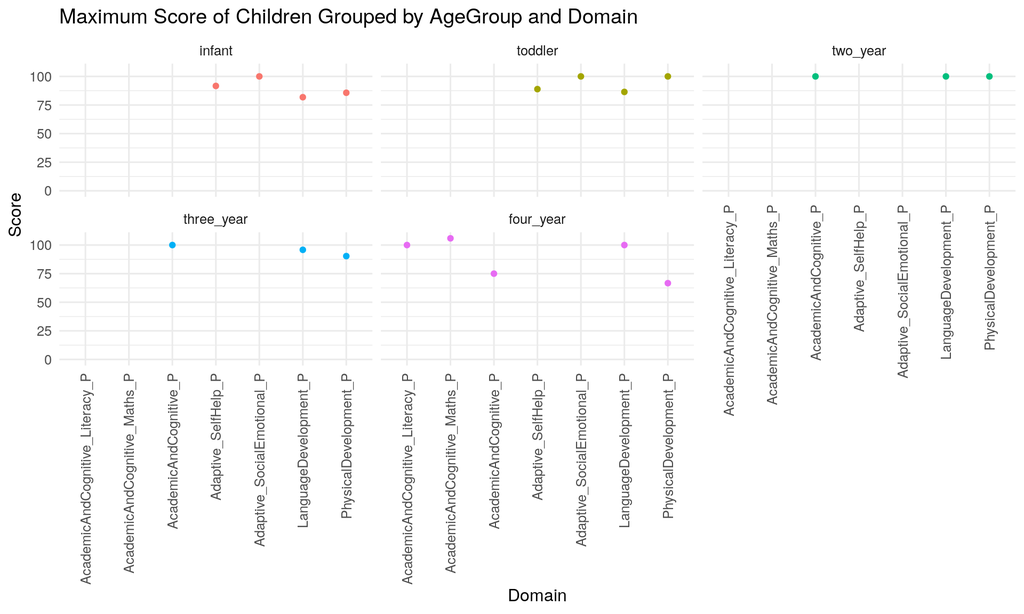

```r
ggplot(UMCH_stat, aes(x = Domain,  y = Max, color=AgeGroup)) +
  geom_point() +
  facet_wrap(~AgeGroup) +
  labs(title="Maximum Score of Children Grouped by AgeGroup and Domain", y="Score") +
  theme(legend.position = "none",
        axis.text.x = element_text(angle = 90, vjust = 0.5, hjust=1)) +
  expand_limits(y = 0)
```

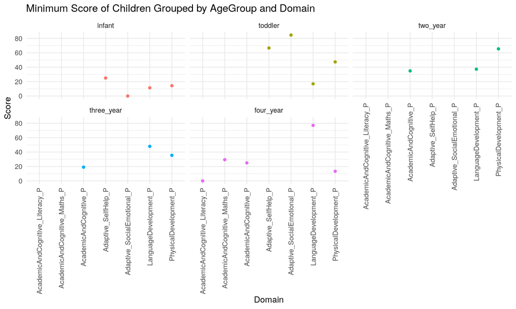

```r
ggplot(UMCH_stat, aes(x = Domain,  y = Min, color=AgeGroup)) +
  geom_point() +
  facet_wrap(~AgeGroup) +
  labs(title="Minimum Score of Children Grouped by AgeGroup and Domain", y="Score") +
  theme(legend.position = "none",
        axis.text.x = element_text(angle = 90, vjust = 0.5, hjust=1)) +
  expand_limits(y = 0)
```

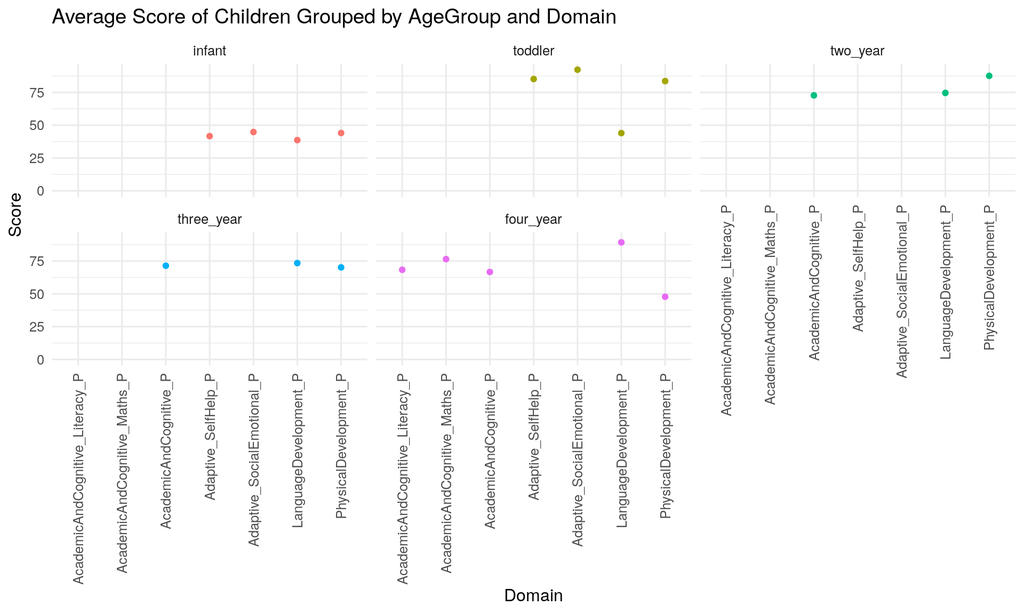

```r
ggplot(UMCH_stat, aes(x = Domain,  y = Mean, color=AgeGroup)) +
  geom_point() +
  facet_wrap(~AgeGroup) +
  labs(title="Average Score of Children Grouped by AgeGroup and Domain", y="Score") +
  theme(legend.position = "none",
        axis.text.x = element_text(angle = 90, vjust = 0.5, hjust=1)) +
  expand_limits(y = 0)
```

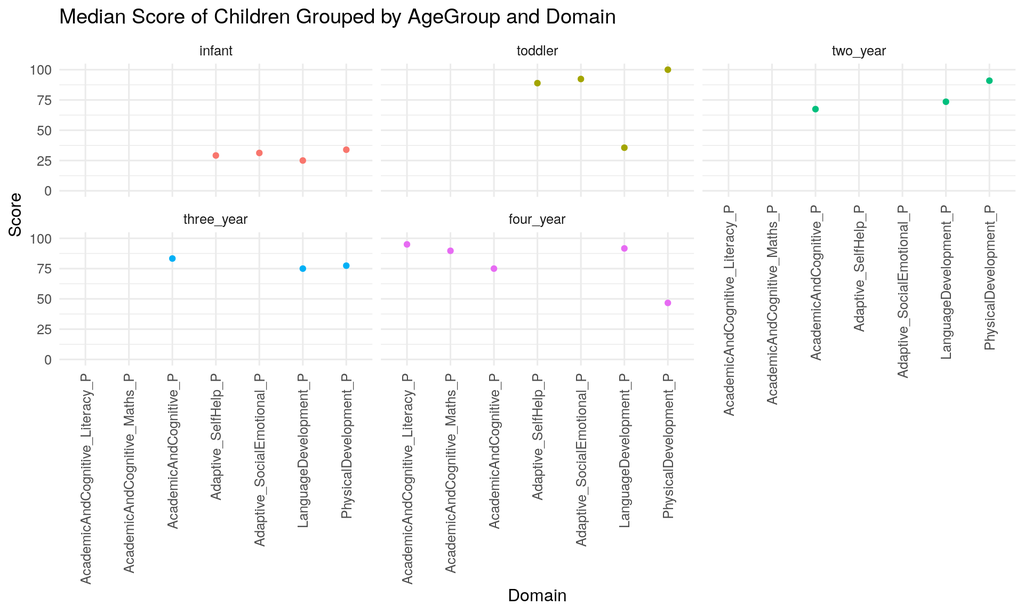

```r
ggplot(UMCH_stat, aes(x = Domain,  y = Median, color=AgeGroup)) +
  geom_point() +
  facet_wrap(~AgeGroup) +
  labs(title="Median Score of Children Grouped by AgeGroup and Domain", y="Score") +
  theme(legend.position = "none",
        axis.text.x = element_text(angle = 90, vjust = 0.5, hjust=1)) +
  expand_limits(y = 0)
```

#### How does score vary by age group?

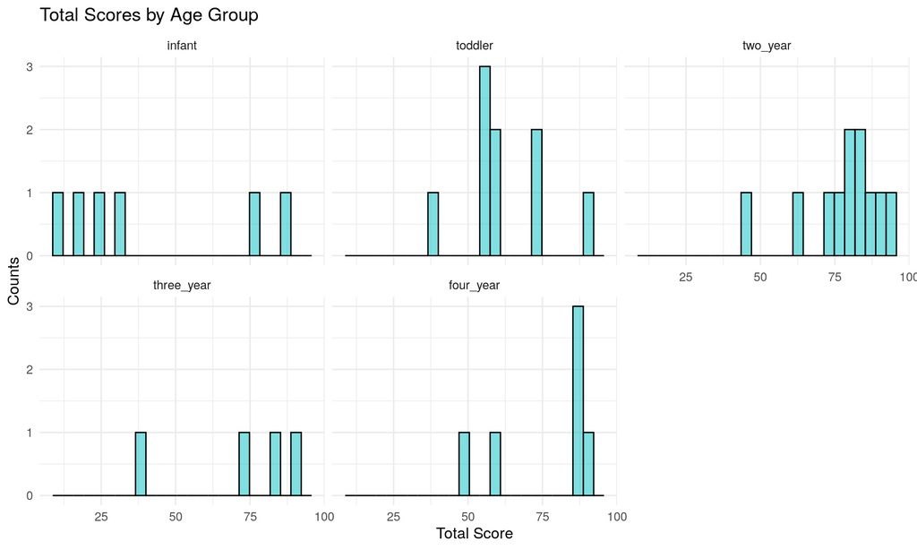

```r
gf_histogram(~TotalScore, data=UMCH, fill='#00BFC4', color='black') %>%
  gf_labs(title="Total Scores by Age Group", x="Total Score", y="Counts") + facet_wrap(~AgeGroup)
```

#### How does score vary by gender?

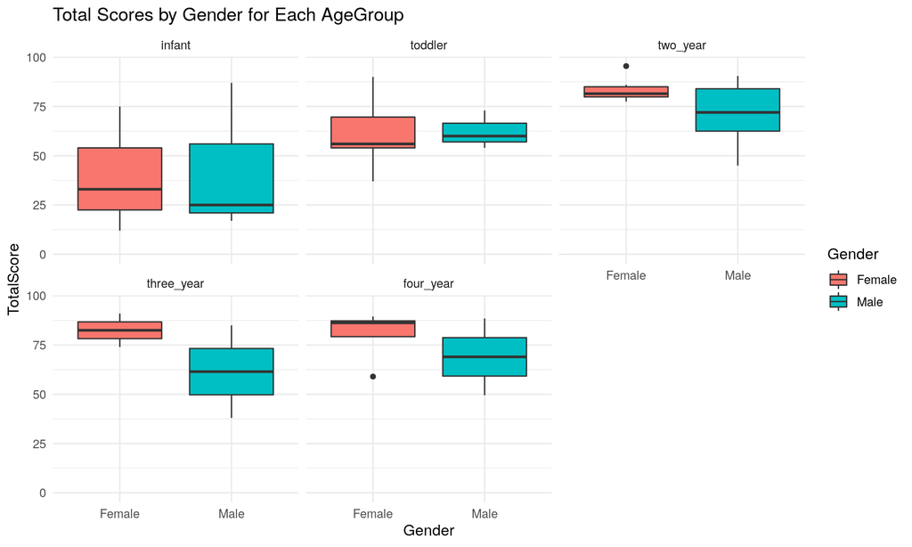

```r
ggplot(UMCH, aes(x = Gender,  y = TotalScore, fill=Gender)) +
  geom_boxplot() +
  facet_wrap(~AgeGroup) +
  labs(title="Total Scores by Gender for Each AgeGroup", x="Gender") +
  expand_limits(y = 0)
```

## TotalScore Model

We used linear regression model because it is used to show/predict the relationship between variables where the response variable is continuous. We can use up to 2 predictors given the size of the data (36/15). We will not add any interaction or random effect due to the size of the dataset. Our predictors will be Age and Gender because all other variables contributes to the Total Score which does not make logical sense to include those.  
Response variable: TotalScore Predictor(s): Age, Gender  
Regression model: Linear regression

```r
mod_total <- lm(TotalScore ~ Age + Gender,
          data = UMCH)
summary(mod_total)
```

```
##
## Call:
## lm(formula = TotalScore ~ Age + Gender, data = UMCH)
##
## Residuals:
##     Min      1Q  Median      3Q     Max
## -42.971 -11.387   3.447  12.380  39.316
##
## Coefficients:
##             Estimate Std. Error t value Pr(>|t|)
## (Intercept)   54.971      6.700   8.205 1.79e-09 ***
## Age            7.990      2.629   3.039  0.00461 **
## GenderMale    -7.287      6.902  -1.056  0.29872
## ---
## Signif. codes:  0 '***' 0.001 '**' 0.01 '*' 0.05 '.' 0.1 ' ' 1
##
## Residual standard error: 20.4 on 33 degrees of freedom
## Multiple R-squared:  0.2436, Adjusted R-squared:  0.1977
## F-statistic: 5.313 on 2 and 33 DF,  p-value: 0.009995
```

## Model Assessment

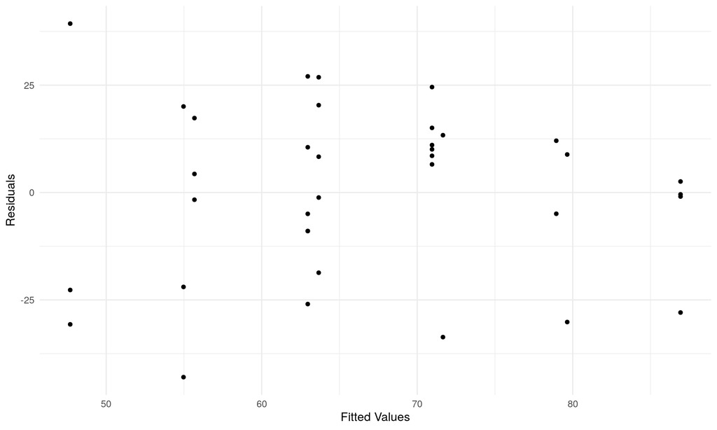

```r
gf_point(resid(mod_total) ~ fitted(mod_total)) %>%
  gf_labs(x = 'Fitted Values', y = 'Residuals')
```

The fitted values vs. the residual plot is used for linearity and error variance. There is no trumpeting present so it passes the error variance condition. However, there is some clustering present and the data points make vertical lines so linearity is a little more iffy on whether or not it passes.

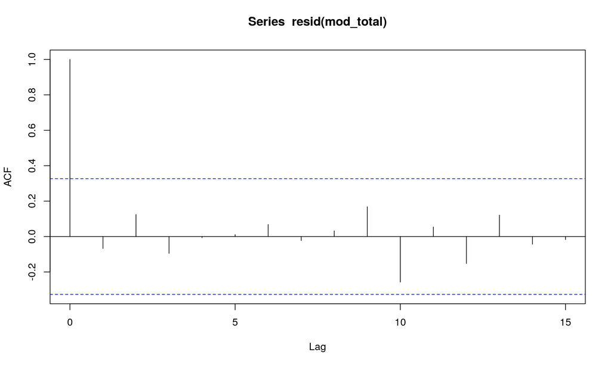

```r
acf(resid(mod_total))
```

Looking at the acf plot, the plot passes the independence condition. All the lines are within the dotted lines and the lag at 0 is normal.

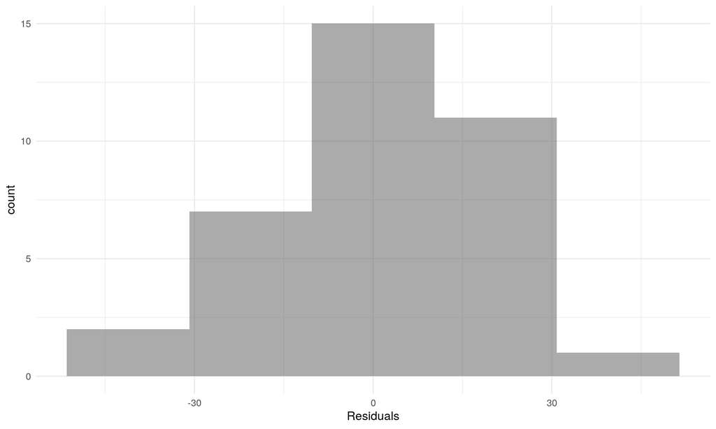

```r
gf_histogram(~resid(mod_total), bins = 5) %>%
  gf_labs(x = "Residuals")
```

Since the data is limited, the bins need to be limited. The histogram passes the normality condition.

## Prediction Plot

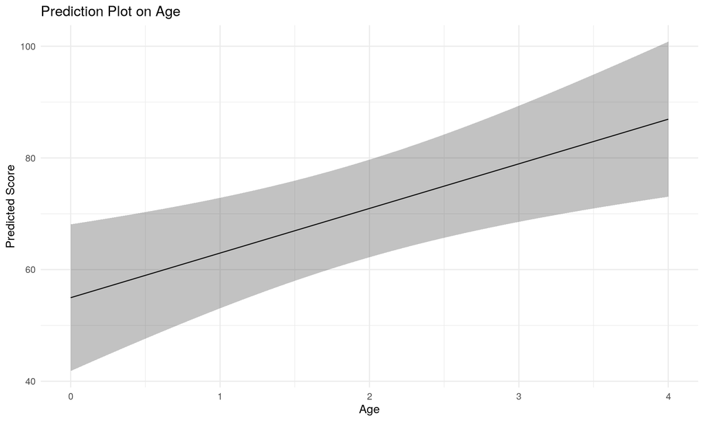

```r
pred_plot(mod_total, 'Age') %>%
  gf_labs(y = 'Predicted Score',
          title = 'Prediction Plot on Age')
```

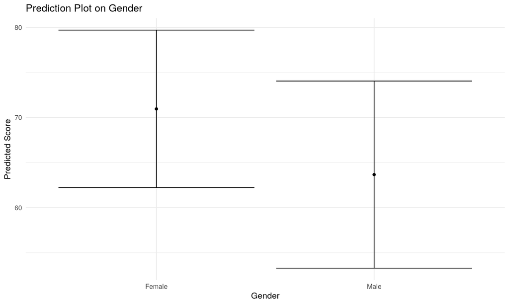

```r
pred_plot(mod_total, 'Gender') %>%
  gf_labs(y = 'Predicted Score',
          title = 'Prediction Plot on Gender')
```

According to the prediction plot for Age, there seems to be a positive trend between the score and age where as age increases, the score also increases. This makes sense because the “pass” score for each age group differs according to the age with lower age having the lowest pass score.  
According to the prediction plot for Gender, it looks like the total score is a little higher for female compared to male. However, the overlapping range is high and the number of children is not the same (21 females and 15 males), so it brings down the reliability score of this data but it is worth noting.